# Reproducible_Research_Assignment_1

Pratik Nirhali

February 19, 2017

## Intorduction

It is now possible to collect a large amount of data about personal movement using activity monitoring devices such as a [Fitbit](http://www.fitbit.com/), [Nike Fuelband](http://www.nike.com/us/en_us/c/nikeplus-fuelband), or [Jawbone Up](https://jawbone.com/up). These type of devices are part of the “quantified self” movement - a group of enthusiasts who take measurements about themselves regularly to improve their health, to find patterns in their behavior, or because they are tech geeks. But these data remain under-utilized both because the raw data are hard to obtain and there is a lack of statistical methods and software for processing and interpreting the data.

## Loading the data

```r
activity <- read.csv ("activity.csv", header = T, sep = ",", stringsAsFactors = F)
```

Process data

```r
totalSteps <- aggregate(steps ~ date, data = activity, sum, na.rm = TRUE)
```

## Analysis

### What is mean total number of steps taken per day?

Make a histogram of the total number of steps taken each day

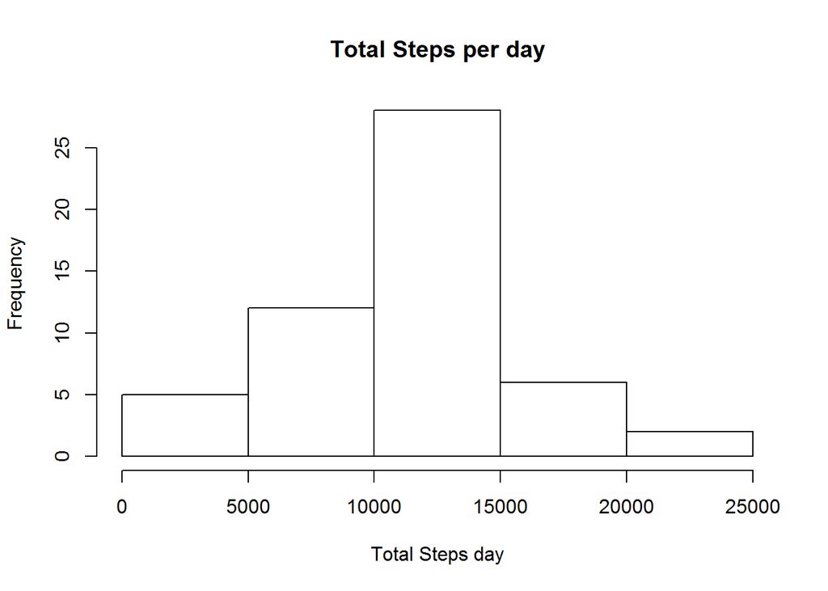

```r
hist(totalSteps$steps,main="Total Steps per day",xlab="Total Steps day",cex.axis=1,cex.lab = 1)
```

```r
mean_steps <- mean(totalSteps$steps)
median_steps <- median(totalSteps$steps)
```

### What is the average daily activity pattern?

Make a time series plot (i.e. type = “l”) of the 5-minute interval (x-axis) and the average number of steps taken, averaged across all days (y-axis)

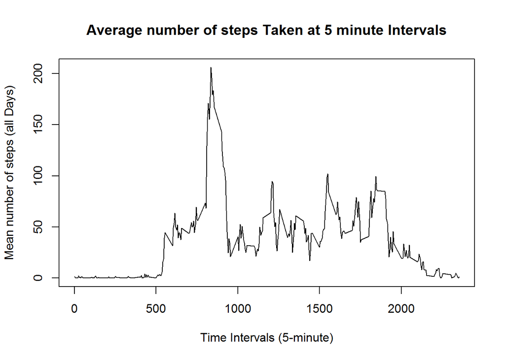

```r
steps_interval <- aggregate(steps ~ interval, data = activity, mean, na.rm = TRUE)
plot(steps ~ interval, data = steps_interval, type = "l", xlab = "Time Intervals (5-minute)", ylab = "Mean number of steps (all Days)", main = "Average number of steps Taken at 5 minute Intervals")
```

```r
maxStepInterval <- steps_interval[which.max(steps_interval$steps),"interval"]
```

### Imputing missing values

```r
missing_rows <- sum(!complete.cases(activity))
```

Devise a strategy for filling in all of the missing values in the dataset. The strategy does not need to be sophisticated. For example, you could use the mean/median for that day, or the mean for that 5-minute interval, etc.

```r
## This function returns the mean steps for a given interval
getMeanStepsPerInterval <- function(interval){
    steps_interval[steps_interval$interval==interval,"steps"]
}
```

Create a new dataset that is equal to the original dataset but with the missing data filled in.

```r
complete.activity <- activity

## Filling the missing values with the mean for that 5-minute interval
flag = 0
for (i in 1:nrow(complete.activity)) {
    if (is.na(complete.activity[i,"steps"])) {
        complete.activity[i,"steps"] <- getMeanStepsPerInterval(complete.activity[i,"interval"])
        flag = flag + 1
        }
}
```

Make a histogram of the total number of steps taken each day.

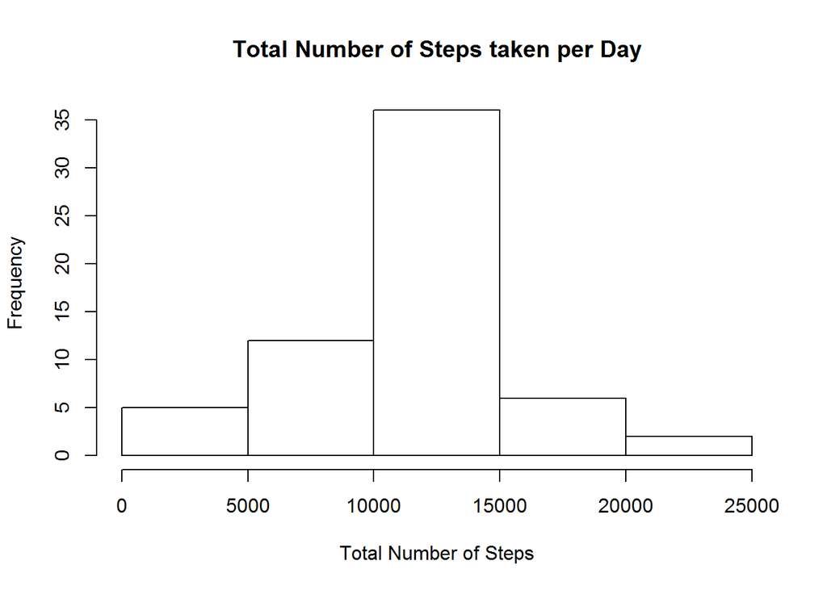

```r
total.steps.per.days <- aggregate(steps ~ date, data = complete.activity, sum)
hist(total.steps.per.days$steps, xlab = "Total Number of Steps",
     ylab = "Frequency", main = "Total Number of Steps taken per Day")
```

```r
showMean <- mean(total.steps.per.days$steps)
showMedian <- median(total.steps.per.days$steps)
```

What is the impact of imputing missing data on the estimates of the total daily number of steps?  
Ans: The mean value is the same as the value before imputing missing data since the mean value has been used for that particular 5-min interval. The median value is different, since the median index is now being changed after imputing missing values.

### Are there differences in activity patterns between weekdays and weekends?

Create a new factor variable in the dataset with two levels - “weekday”" and “weekend”" indicating whether a given date is a weekday or weekend day.

```r
complete.activity$day <- ifelse(as.POSIXlt(as.Date(complete.activity$date))$wday%%6 ==
                                    0, "weekend", "weekday")
complete.activity$day <- factor(complete.activity$day, levels = c("weekday", "weekend"))
```

Make a panel plot containing a time series plot (i.e. type = “l”) of the 5-minute interval (x-axis) and the average number of steps taken, averaged across all weekday days or weekend days (y-axis).

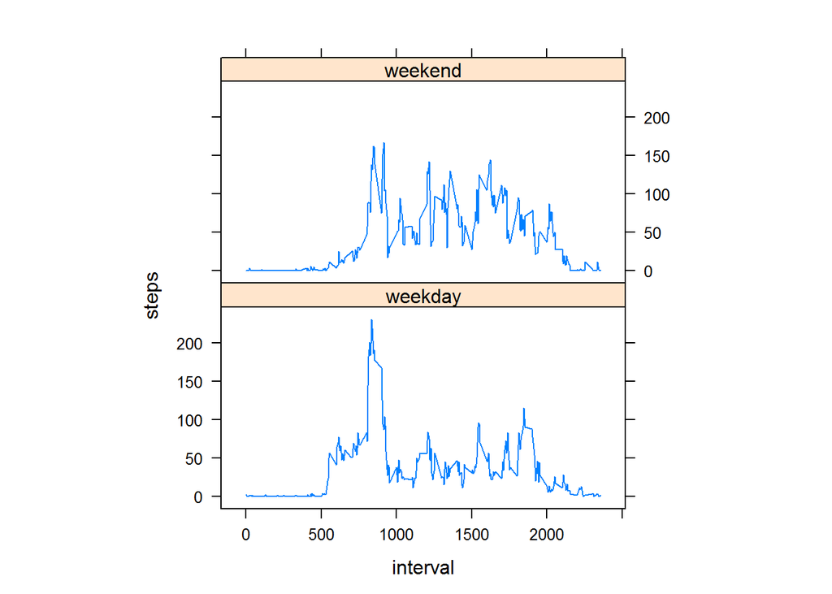

```r
steps.interval= aggregate(steps ~ interval + day, complete.activity, mean)
library(lattice)
xyplot(steps ~ interval | factor(day), data = steps.interval, aspect = 1/2,
       type = "l")
```